# Changes in R

We present important changes in the development version of R (referred to as R-devel, to become R 4.3). Some statistics on bug tracking activities in 2022 are also provided.

Tomas Kalibera (R Core) , Sebastian Meyer (Friedrich-Alexander-Universität Erlangen-Nürnberg) , Kurt Hornik (WU Wirtschaftsuniversität Wien)  
2022-12-01

# 1 R-devel selected changes

R 4.3.0 is due to be released around April 2023. The following gives a selection of the most important changes in R-devel, which are likely to appear in the new release.

## Dates and times

There are a number of (robustness) improvements in the handling of dates and times. These include warnings about extrapolation for datetimes before 1902/1900, finer control for padding when printing years, improved detection of offset with `strftime()` (`%z`), inclusion of system time zone and information on timezone support implementation in `sessionInfo()`, more robust handling of hand-crafted `POSIXlt` objects, optional support for using system timezone support on recent macOS, improved detection of the system time zone on Windows and improved default tick locations and default formats in `axis.Date()` and `axis.POSIXct()`.

## Encoding support

- Performance of regular expression operations in R has been improved by reducing the costs of encoding conversions. With `perl=FALSE`, all inputs have to be converted to UTF-16 or UTF-32, and the conversion is now faster. With `perl=TRUE`, performance has been improved by opting out from duplicate checks for UTF-8 validity in PCRE2. With `fixed=TRUE`, performance has been improved by taking advantage of the properties of UTF-8. One of the motivations for the speedups was to reduce the incentive for using `useBytes=TRUE` with regular expression operations, which often leads to incorrect results or errors due to producing invalid strings.

  See [Speedups in operations with regular expressions](https://blog.r-project.org/2022/07/12/speedups-in-operations-with-regular-expressions) for more information.
- The support for encoding-agnostic string operations in R using the “bytes” encoding has been improved. It is now possible to read a text file directly as bytes. Regexp operations, when creating new strings by splitting or substituting, now also flag them as “bytes” when any of the input has been flagged as such. This simplifies encoding-agnostic parsing of files such as `DESCRIPTION`. `iconv(,from="")` now respects the encoding flag of the input string, making it easier to recover from type-instability in return values of regular expression operations. Improving the support for encoding-agnostic operations using the “bytes” encoding comes together with stricter checking of validity of real strings in a character encoding, e.g. “unknown/native”, which has been helpful in revealing user errors. In the long term, it should also help to simplify encoding support in R.

  See [Improvements in handling bytes encoding](https://blog.r-project.org/2022/10/10/improvements-in-handling-bytes-encoding) for more information. The blog includes a detailed introduction to string and encoding support in R.

  See [Why to avoid \x in regular expressions](https://blog.r-project.org/2022/06/27/why-to-avoid-%5Cx-in-regular-expressions/) for related information on the danger of using `\x` escapes in regular expressions, which leads to errors, that are now more likely to be detected by R. This is closely related as `\x` is a common way to create invalid strings.

## Graphics

- The grDevices and grid packages have new functions for rendering typeset glyphs, primarily: `grDevices::glyphInfo()` and `grid::grid.glyph()`.
- The behaviour of compositing operators in `grid::grid.group()` has been tweaked to allow consistency across graphics devices.
- The `grDevices::quartz()` device will support gradient fills, pattern fills, clipping paths, masks, compositing operators, affine transformations, stroked/filled paths, and glyphs. To be soon merged to R-devel.

## Accessibility on Windows

- `Rgui` console on Windows now works better with the open-source NVDA screen reader when the “full” blinking cursor is selected. This is due to improved implementation of the console cursor (when it is displayed and hidden with respect to application startup and window focus) on which makes it easier for the screen reader to detect where the cursor is. Previously, NVDA was not able to read out the character under the cursor moved by the arrow keys.
- The drop-field GraphApp control, which is used in the `Rgui` configuration editor, has been extended so that it can be left by pressing the TAB key, so without using the mouse.
- GraphApp has been extended to allow reverse-order navigation through the controls using Shift+TAB key, which can now be done also in the `Rgui` configuration editor.

## Other selected changes

- Using vectors of more than one element with the logical operators `&&` and `||` will give an error in R 4.3.0 (a warning in R 4.2.x, a check error since R 3.6.0).
- Support for working with concordances has been extended from Sweave to help files. A concordance is a mapping between lines in an intermediate file (e.g., `.tex` or `.html`) and lines in the corresponding input file (e.g., `.Rnw` or `.Rd`), which, for example, allows relating problems in the intermediate file to the source file from which it was generated.

  See [Concordances](https://blog.r-project.org/2022/10/20/concordances) for more information.
- The implementation of the sampling profiler, `Rprof()`, has been improved. On macOS, the profiler is now more robust against high load on the system by using low-level Mach API to avoid a race condition between initialization of pthread data and arrival of a profiler signal. This race condition could lead to a live-lock when the system has been overloaded due to a too short profiling interval. As an additional measure, `Rprof()` now refuses to use a too short profiling interval, which in the first place would lead to incorrect profiling results. To prevent a deadlock seen on Windows, the profiler has been rewritten to avoid using C runtime functions while the main thread is suspended.
- Package installation now uses C++17 as the default C++ standard (and there is initial support for C++23). Also, there now is support for a package to indicate the version of the C standard which should be used to compile it, and for the installing user to specify this. In most cases, C17 (a “bug-fix” of C11) is used by default.
- Producing PDF manuals (`R CMD Rd2pdf`) now loads standard AMS-LaTeX packages for greater coverage of math commands in Rd equations (e.g., `\lVert` and `\text`), and for consistency with the enhanced HTML math rendering introduced in R 4.2.0. This change has been backported to the R 4.2 release branch.
- The `"repos"` option is now initialized from the `repositories` file, see `?R_REPOSITORIES`, allowing the default CRAN mirror to be set therein.

# 2 Bug statistics for 2022

Summaries of bug-related activities over the past year were derived from the database underlying [R’s Bugzilla system](https://bugs.R-project.org/). Overall, 180 new bugs or requests for enhancements were reported, 171 reports were closed, and 869 comments (on any report) were added by a total of 123 contributors. This amounts to one report/closure every other day, and 2–3 comments per day. The numbers of reports, closures and comments are about 20% lower than in 2021, whereas the number of contributors stayed the same. High bug activity in 2021 had largely been driven by dedicated efforts of several contributors in reviewing old reports.

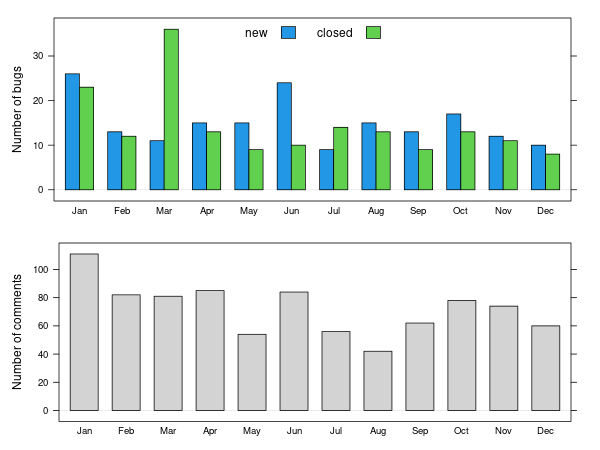

Figure 1: Bug tracking activity by month in 2022

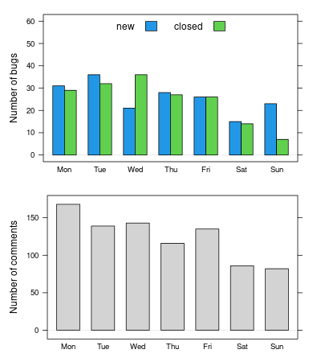

Figure 2: Bug tracking activity by weekday in 2022

Figures 1 and 2 show statistics for the numbers of new reports, closures and comments by calendar month and weekday, respectively, in 2022. The frequency of new reports was relatively stable over the year with minor peaks in January and June. There tended to be more new reports than closures, except for July and especially March with a revived effort to deal with old reports, including 9 related to the nlme package, which is also maintained by the R Core Team.

The top 5 components reporters have chosen for their reports were “Misc”, “Language”, “Low-level”, “Documentation”, and “Wishlist”, which is the same set as in 2021. Many reports are suggestions for enhancements and placed either in the “Wishlist” or in a specific component but with severity level set to “enhancement”. Bug discussions led to an average of 72 comments per month, with a minimum of 42 in August and a maximum of 111 in January. From the numbers in Figure 2 we see that the R community is also active during weekends, though at a lower frequency.

# Acknowledgements

Tomas Kalibera’s work on the article and R development has received funding from the National Science Foundation award 1925644.

## CRAN packages used

nlme

## CRAN Task Views implied by cited packages

ChemPhys, Econometrics, Environmetrics, Finance, MixedModels, OfficialStatistics, Psychometrics, Spatial, SpatioTemporal